# R Notebook

# **Problema de negócio: Criar um algoritmo que possa prever se um usuário fará o download de um aplicativo para dispositivos móveis depois de clicar em um determinado anúncio.**

```r
# Definindo diretório de trabalho
options(warn=-1)
setwd("C:/Users/Thiago Pereira/Desktop/dsa/BigDataRAzure/Projeto 1")
getwd()
```

```
## [1] "C:/Users/Thiago Pereira/Desktop/dsa/BigDataRAzure/Projeto 1"
```

```r
# Carregando pacotes
library(readr)
library(dplyr)
library(lubridate)
library(ggplot2)
library(Hmisc)
library(ggpubr)
library(gridExtra)
library(treemap)
library(grid)
library(forcats)
library(corrplot)
library(tidyr)
```

```r
# Carregando os dados
df <- read_csv('train_sample.csv')
```

```r
head(df)
```

| ip | app | device | os | channel | click_time | attributed_time | is_attributed |
| --- | --- | --- | --- | --- | --- | --- | --- |
| 87540 | 12 | 1 | 13 | 497 | 2017-11-07 09:30:38 |  | 0 |
| 105560 | 25 | 1 | 17 | 259 | 2017-11-07 13:40:27 |  | 0 |
| 101424 | 12 | 1 | 19 | 212 | 2017-11-07 18:05:24 |  | 0 |
| 94584 | 13 | 1 | 13 | 477 | 2017-11-07 04:58:08 |  | 0 |
| 68413 | 12 | 1 | 1 | 178 | 2017-11-09 09:00:09 |  | 0 |
| 93663 | 3 | 1 | 17 | 115 | 2017-11-09 01:22:13 |  | 0 |

```r
# Dimensões do df
dim(df)
```

```
## [1] 100000      8
```

```r
# Tipos das colunas
str(df)
```

```
## tibble [100,000 x 8] (S3: spec_tbl_df/tbl_df/tbl/data.frame)
##  $ ip             : num [1:100000] 87540 105560 101424 94584 68413 ...
##  $ app            : num [1:100000] 12 25 12 13 12 3 1 9 2 3 ...
##  $ device         : num [1:100000] 1 1 1 1 1 1 1 1 2 1 ...
##  $ os             : num [1:100000] 13 17 19 13 1 17 17 25 22 19 ...
##  $ channel        : num [1:100000] 497 259 212 477 178 115 135 442 364 135 ...
##  $ click_time     : POSIXct[1:100000], format: "2017-11-07 09:30:38" "2017-11-07 13:40:27" ...
##  $ attributed_time: POSIXct[1:100000], format: NA NA ...
##  $ is_attributed  : num [1:100000] 0 0 0 0 0 0 0 0 0 0 ...
##  - attr(*, "spec")=
##   .. cols(
##   ..   ip = col_double(),
##   ..   app = col_double(),
##   ..   device = col_double(),
##   ..   os = col_double(),
##   ..   channel = col_double(),
##   ..   click_time = col_datetime(format = ""),
##   ..   attributed_time = col_datetime(format = ""),
##   ..   is_attributed = col_double()
##   .. )
```

Descrições sobre as colunas:

ip: endereço ip do click  
app: id do aplicátivo para marketing  
device: tipo do celular, ex: Iphone 6 plus, Iphone 7 plus, Hawuei mate 7, etc…  
os: versão do so do aparelho celular  
channel: id do canal do editor de anúncios para celular  
click_time: hora do click no anúncio(utc)  
attributed_time: se o usuário fez o download do app depois de clicar no ad, hora do download do app  
is_attributed: variável alvo a ser predita, indicando se o app foi baixado  
OBS: ip, app, device, os e channel são dados encriptografados.

# Análise Exploratória

### Qual a porcentagem de ips duplicados em relação ao conjunto de dados?

```r
duplicated_ips <- df[duplicated(df$ip),]
length(duplicated_ips$ip) / length(df$ip)
```

```
## [1] 0.65143
```

```r
#65% da base de dados são ip duplicados.
```

### Qual a porcentagem de ocorrências da variável alvo (is_attributed == 1) em relação ao conjunto de dados?

```r
nrow(filter(df, is_attributed == 1)) / nrow(df)
```

```
## [1] 0.00227
```

```r
# Observa-se um fenômeno em que a variável alvo é rara com 0.22% de ocorrência.
```

### Usuários que acessam mais de uma vez, tem maior porcentagem de conversão (realizar o download do app)?

```r
df$ip_duplicado = ifelse(duplicated(df$ip), 1, 0)
grouped_1 <- df %>% group_by(is_attributed, ip_duplicado) %>% summarise(count = n())
grouped_1
```

| is_attributed | ip_duplicado | count |
| --- | --- | --- |
| 0 | 0 | 34687 |
| 0 | 1 | 65086 |
| 1 | 0 | 170 |
| 1 | 1 | 57 |

```r
# É possível observar que o volume para variável alvo(is_attributed) == 0 e o "ip" é duplicado(ip_duplicado == 1) é
# quase 2x maior comparado à variável alvo(is_attributed) == 0 e o "ip" não é duplicado(ip_duplicado == 0).
# No caso da variável alvo(is_attributed == 1) ocorre ao contrário, usuários que fazem o download do aplicativo, acabam
# não acessando o anúncio mais de uma vez.
# Conclusão:
# 1) Usuários que acessam o anúncio e não o consomem, acabam acessando-o por mais vezes e mesmo assim não baixam o aplicativo.
# 2) A maioria dos usuários que acessam o anúncio e acabam consumindo o conteúdo do anúncio, só acessam este anúncio uma única vez.
# A variável ip_duplicado será de grande valia, pois quando o registro for 0, o usuário terá maiores chances de realizar o download# do aplicativo. OBS: NÃO INDICA CAUSALIDADE.
```

# Qual a média e mediana em minutos que o usuário leva para acessar o anúncio e fazer o download do app?

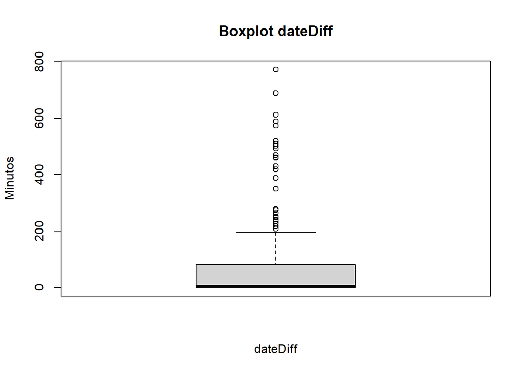

```r
df$dateDiff <- ifelse(is.na(df$attributed_time), 0, difftime(df$attributed_time, df$click_time, units = "mins"))
boxplot(df %>% filter(dateDiff > 0) %>% select(dateDiff), main = "Boxplot dateDiff", xlab = "dateDiff", ylab = "Minutos")
```

```r
# Média em minutos que o usuário leva para fazer o download depois de clicar no anúncio:
lapply(df %>% filter(dateDiff > 0) %>% select(dateDiff), mean)
```

```
## $dateDiff
## [1] 74.99288
```

```r
# Visualizando o boxplot, percebe-se a ocorrência de muitos outliers que acabam puxando
# a média para cima, 74.99288 minutos, o que não é bom para mensurarmos esse tempo.
# Mediana em minutos que o usuário leva para fazer o download depois de clicar no anúncio:
lapply(df %>% filter(dateDiff > 0) %>% select(dateDiff), median)
```

```
## $dateDiff
## [1] 3.3
```

```r
# A melhor medida para mensurarmos o tempo em que o usuário leva para
# clicar no anúncio e realizar o download do aplicativo é de 3.3 minutos, segundo a mediana.
```

## Quantos dias de registros existem nesses dados?

```r
difftime(max(df$click_time), min(df$click_time), units="days")
```

```
## Time difference of 2.999896 days
```

```r
# Temos 3 dias de registros nesses dados.
```

## Qual a distribuição do volume de cliques por hora para cada dia?

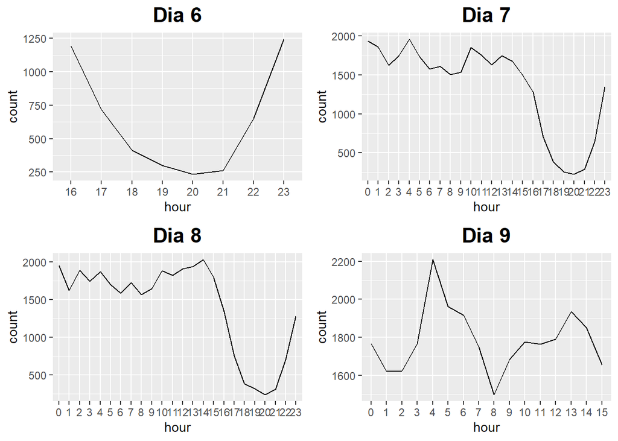

```r
df$day <- factor(day(as.POSIXct(df$click_time, format = "%Y/%m/%d")))
df$hour <- factor(hour(as.POSIXct(df$click_time, format = "%Y/%m/%d")))
clicks_by_day <- df %>% group_by(day) %>% summarise(clicks_dia = n())
# Filtrando cada dia para análise indivual
day_6 <- df %>% filter(day == "6")
day_6 <- day_6 %>% group_by(hour) %>% summarise(count = n())

day_7 <- df %>% filter(day == "7")
day_7 <- day_7 %>% group_by(hour) %>% summarise(count = n())

day_8 <- df %>% filter(day == "8")
day_8 <- day_8 %>% group_by(hour) %>% summarise(count = n())

day_9 <- df %>% filter(day == "9")
day_9 <- day_9 %>% group_by(hour) %>% summarise(count = n())
# Construindo os gráficos
chart_day6 <- ggplot(day_6, aes(x = hour, y = count, group = 1)) +
  geom_line() +
  ggtitle("Dia 6")+
  theme(plot.title = element_text(hjust = 0.5, size = 17, face = "bold"))

chart_day7 <- ggplot(day_7, aes(x = hour, y = count, group = 1)) +
  geom_line() +
  ggtitle("Dia 7")+
  theme(plot.title = element_text(hjust = 0.5, size = 17, face = "bold"))
chart_day8 <- ggplot(day_8, aes(x = hour, y = count, group = 1)) +
  geom_line() +
  ggtitle("Dia 8")+
  theme(plot.title = element_text(hjust = 0.5, size = 17, face = "bold"))

chart_day9 <- ggplot(day_9, aes(x = hour, y = count, group = 1)) +
  geom_line() +
  ggtitle("Dia 9")+
  theme(plot.title = element_text(hjust = 0.5, size = 17, face = "bold"))

grid.arrange(chart_day6, chart_day7, chart_day8, chart_day9, nrow = 2, ncol = 2)
```

```r
# Os volumes de clicks por hora, a cada dia, seguem a mesma distribuição.
```

### Qual o volume de downloads por hora para cada dia?

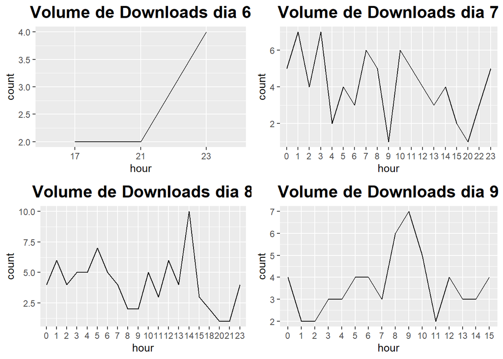

```r
# Filtrando dias individuais quando is_attributed == 1 para análises.
alvo1_day6 <- df %>% filter(day == "6", is_attributed == 1) %>%
  group_by(hour) %>%
  summarise(count = n())

alvo1_day7 <- df %>% filter(day == "7", is_attributed == 1) %>%
  group_by(hour) %>%
  summarise(count = n())

alvo1_day8 <- df %>% filter(day == "8", is_attributed == 1) %>%
  group_by(hour) %>%
  summarise(count = n())

alvo1_day9 <- df %>% filter(day == "9", is_attributed == 1) %>%
  group_by(hour) %>%
  summarise(count = n())
# Construindo os gráficos para análise
chart_alvo1_day6 <- ggplot(alvo1_day6, aes(x = hour, y = count, group = 1)) +
  geom_line() +
  ggtitle("Volume de Downloads dia 6")+
  theme(plot.title = element_text(hjust = 0.5, size = 17, face = "bold"))

chart_alvo1_day7 <- ggplot(alvo1_day7, aes(x = hour, y = count, group = 1)) +
  geom_line() +
  ggtitle("Volume de Downloads dia 7")+
  theme(plot.title = element_text(hjust = 0.5, size = 17, face = "bold"))

chart_alvo1_day8 <- ggplot(alvo1_day8, aes(x = hour, y = count, group = 1)) +
  geom_line() +
  ggtitle("Volume de Downloads dia 8")+
  theme(plot.title = element_text(hjust = 0.5, size = 17, face = "bold"))

chart_alvo1_day9 <- ggplot(alvo1_day9, aes(x = hour, y = count, group = 1)) +
  geom_line() +
  ggtitle("Volume de Downloads dia 9")+
  theme(plot.title = element_text(hjust = 0.5, size = 17, face = "bold"))

grid.arrange(chart_alvo1_day6, chart_alvo1_day7, chart_alvo1_day8, chart_alvo1_day9, nrow = 2, ncol = 2)
```

```r
# .
```

### Em quais horas, o volume de downloads do aplicativo são maiores?

```r
downloads_byHour <- df %>% filter(is_attributed == 1)
downloads_byHour <- downloads_byHour %>% group_by(hour) %>% summarise(clicks_hour = n())
downloads_byHour
```

| hour | clicks_hour |
| --- | --- |
| 0 | 13 |
| 1 | 15 |
| 2 | 10 |
| 3 | 15 |
| 4 | 10 |
| 5 | 15 |
| 6 | 12 |
| 7 | 13 |
| 8 | 13 |
| 9 | 10 |

[output cut: 12 more lines]

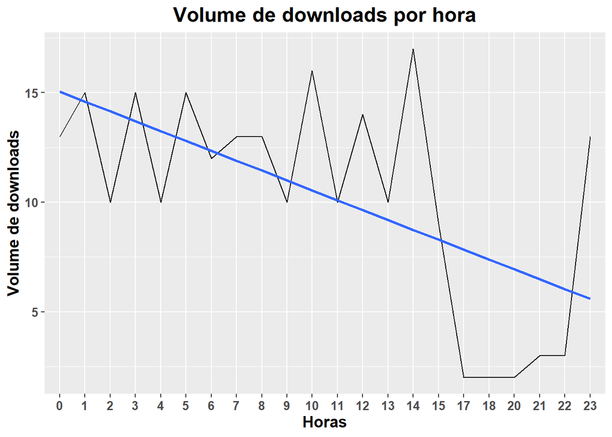

```r
g2 <- ggplot(downloads_byHour, aes(x = hour, y = clicks_hour, group = 1)) +
  geom_line() +
  labs(x = "Horas", y = "Volume de downloads") +
  ggtitle("Volume de downloads por hora") +
  theme(plot.title = element_text(hjust = 0.5, size = 17, face = "bold"),
        axis.text.x = element_text(size= 10, face = "bold"),
        axis.text.y = element_text(size= 10, face = "bold"),
        axis.title.x = element_text(size=13, face = "bold"),
        axis.title.y = element_text(size=13, face = "bold")) +
  stat_smooth(method = "lm", size = 1, se = FALSE)
# Plotando o gráfico 2
g2
```

```r
#.
```

Conclusão: O volume de cliques e download variam durante as horas, porém quando chega às 14 horas, o volume cai drasticamente, provavelmente, o volume de pessoas online está menor.  
O momento ideal para se fazer alguma campanha seria após às 0 horas, até às 14, pois o volume de pessoas e pessoas convertidas(download do app), são maiores.

### Qual a distribuição variável app quando is_attributed == 1?

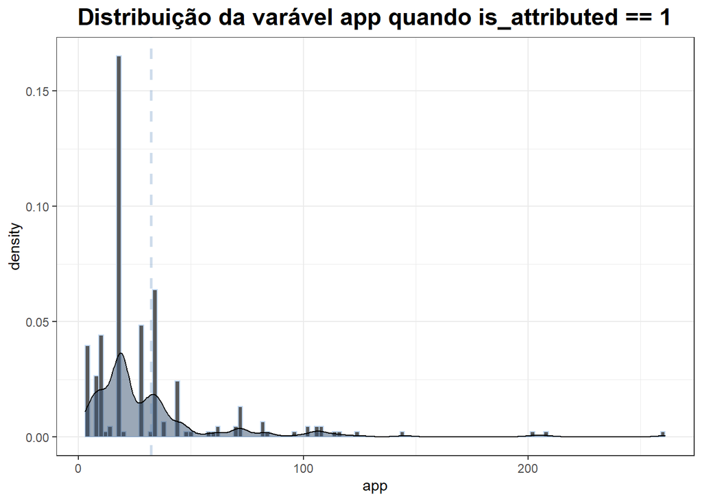

```r
# Construindo histograma
app <- df %>% filter(is_attributed == 1) %>% select(app)
g1 <- ggplot(app, aes(x = app)) +
  geom_histogram(aes(y = ..density..), binwidth = 2, color = "#BFD7F2", position = "identity") +
  theme_bw() +
  xlab("app") +
  geom_density(alpha = .5, fill = "#375270") +
   geom_vline(aes(xintercept=mean(app)),
             color="#5C89BD", linetype="dashed", size=1, alpha = .3) +
  ggtitle("Distribuição da varável app quando is_attributed == 1") +
  theme(plot.title = element_text(hjust = 0.5, size = 17, face = "bold"))

# Plotando histograma para visualizar a densidade de ocorrências em cada faixa de app.
g1
```

```r
order_app <- df %>% filter(is_attributed == 1) %>% group_by(app) %>% summarise(count = n())
order_app$percent <- round(order_app$count / sum(order_app$count), digits=2)
order_app <- order_app[order(order_app$percent, decreasing = TRUE),]
# Visualizando as 10 maiores porcentagens de ocorrência da variável app quando is_attributed == 1
order_app
```

| app | count | percent |
| --- | --- | --- |
| 19 | 70 | 0.31 |
| 35 | 27 | 0.12 |
| 29 | 22 | 0.10 |
| 10 | 18 | 0.08 |
| 5 | 14 | 0.06 |
| 45 | 11 | 0.05 |
| 9 | 8 | 0.04 |
| 72 | 6 | 0.03 |
| 3 | 4 | 0.02 |
| 8 | 4 | 0.02 |

[output cut: 27 more lines]

### Qual a distribuição variável device quando is_attributed == 1?

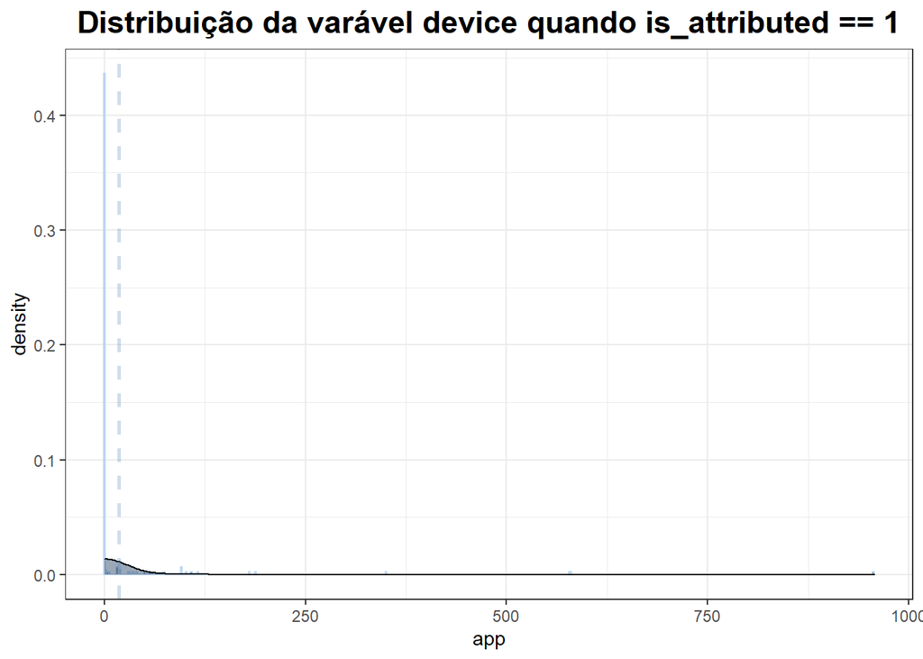

```r
device <- df %>% filter(is_attributed == 1) %>% select(device)
# Construindo histograma para visualização
g1 <- ggplot(device, aes(x = device)) +
  geom_histogram(aes(y = ..density..), binwidth = 2, color = "#BFD7F2", position = "identity") +
  theme_bw() +
  xlab("app") +
  geom_density(alpha = .5, fill = "#375270") +
  geom_vline(aes(xintercept=mean(device)),
             color="#5C89BD", linetype="dashed", size=1, alpha = .3) +
  ggtitle("Distribuição da varável device quando is_attributed == 1") +
  theme(plot.title = element_text(hjust = 0.5, size = 17, face = "bold"))

# Plotando o histograma
g1
```

```r
order_device <- df %>% filter(is_attributed == 1) %>% group_by(device) %>% summarise(count = n())
order_device$percent <- round(order_device$count / sum(order_device$count), digits=2)
order_device <- order_device[order(order_device$percent, decreasing = TRUE),]
# Visualizando as 10 maiores porcentagens de ocorrência da variável device quando is_attributed == 1
order_device
```

| device | count | percent |
| --- | --- | --- |
| 1 | 146 | 0.64 |
| 0 | 52 | 0.23 |
| 2 | 2 | 0.01 |
| 16 | 3 | 0.01 |
| 21 | 2 | 0.01 |
| 97 | 3 | 0.01 |
| 4 | 1 | 0.00 |
| 6 | 1 | 0.00 |
| 30 | 1 | 0.00 |
| 33 | 1 | 0.00 |

[output cut: 15 more lines]